# Assignment 3

Sarah Fondots

February 15, 2019

## Hydraulic Rock Drilling

Two processes for hydraulic drilling of rock are dry drilling and wet drilling. In a dry hole, compressed air is forced down the drill rods to flush the cuttings and drive the hammer; in a wet hole water is forced down. An experiment was conducted to determine whether the time *y* it takes to dry drill a distance of 5 feet in rock increases with depth *x* the results(extracted from *American Statistician*, February 1991) for one portion of the experiment are shown in the dataset.

1. Generate the scatterplot of y (time to drill 5 ft) vs. x (depth at which drilling begins). Describe the graph, and the relationship between x and y. Include the calculated value of the linear correlation, $r$, under the graph.
2. Conduct the complete simple linear regression analysis of the data. This will include the regression equation, a statement about $R^2$ and CV, and the t-test for non-zero slope.
3. Predict time (y) for a depth of $x=300$ feet. Include confidence intervals for both the mean value of $y$ and the individual predicted value of $y$.
4. What is the 95% confidence interval for the slope?
5. Be sure to write up your analysis with complete sentences, grammar, and punctuation. Include all relevant Minitab output.

### #1

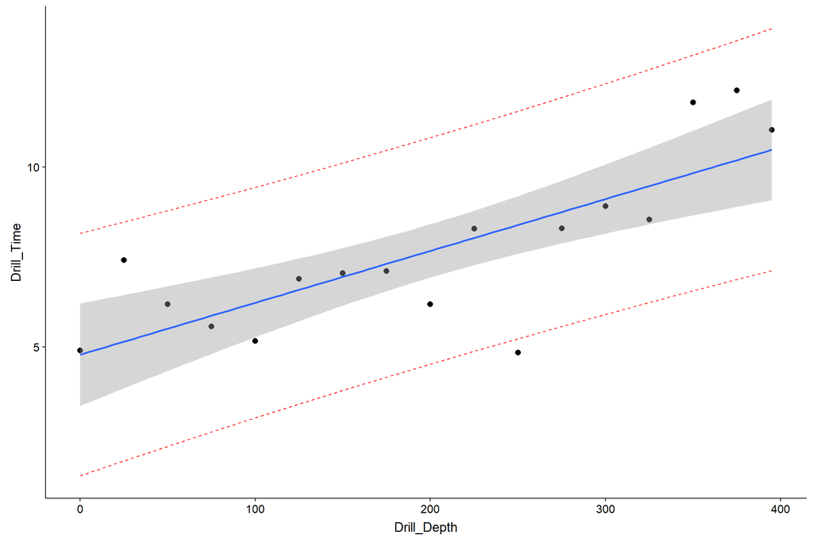

Value of linear correlation is $r$= 0.7937

### #2

|  | Estimate | CI (lower) | CI (upper) | Std. Error | t value | Pr(>\|t\|) |  |
| --- | --- | --- | --- | --- | --- | --- | --- |
| (Intercept) | 4.7896 | 3.3694 | 6.2098 | 0.6663 | 7.188 | <0.001 | *** |
| Drill_Depth | 0.0144 | 0.0083 | 0.0205 | 0.0028 | 5.053 | <0.001 | *** |

### #3

[output not shown]

The predicted time it would take to drill 300 feet given our regression equation is 9.106.

### #4

95% confidence interval for the slope: 0.0083 to 0.0205